# Casting a net to better understand fisheries management: An affiliation network analysis of the Great Lakes Fishery Commission - ScienceDirect

## [Marine Policy](https://www.sciencedirect.com/journal/marine-policy)

[Volume 57](https://www.sciencedirect.com/journal/marine-policy/vol/57/suppl/C), July 2015, Pages 120-131

# Casting a net to better understand fisheries management: An affiliation network analysis of the Great Lakes Fishery Commission

https://doi.org/10.1016/j.marpol.2015.03.008[Get rights and content](https://s100.copyright.com/AppDispatchServlet?publisherName=ELS&contentID=S0308597X15000573&orderBeanReset=true)

Full text access

## Highlights

- •

  The affiliation network of the Great Lakes Fishery Commission is highly complex.
- •

  1516 ties were identified between the GLFC and 149 organizations.
- •

  Both formal and informal relationships are important in the affiliation network.
- •

  Different management and stakeholders contribute different roles to the GLFC network.
- •

  Sportfishing and commercial fishing organizations are important bridges.
- •

  The GLFC and state and federal agencies are important coordinating participants.

## Keywords

Great Lakes fisheries management

Social network analysis

Affiliation networks

Stakeholder engagement

## 1. Introduction

Fisheries and other [natural resource](https://www.sciencedirect.com/topics/earth-and-planetary-sciences/natural-resource) governance is evolving into integrated, stakeholder-based frameworks in which various government agencies interact with the private sector and civil society to influence and make decisions [15]. Diverse participation is important for providing context for social-environmental systems with regard to not only complex [environmental issues](https://www.sciencedirect.com/topics/earth-and-planetary-sciences/environmental-issue), but also social, ethical and economic issues [32]. Additionally, past successful collaborative participation in the decision-making process can improve future processes that may otherwise be polarizing [27].

This increased interaction and collaboration highlight the importance of understanding the formal and informal relationships between natural resource managers and stakeholders for the facilitation of information and resource flows and [policy development](https://www.sciencedirect.com/topics/earth-and-planetary-sciences/policy-development) [11]. Therefore, there is an increased value of taking a social network analysis approach [9] that aids the understanding of relationships among different managers and stakeholders involved with governance and how those relationships hinder or promote good governance of natural resources [11], [19]. This approach increases the understanding of which stakeholders are or could be engaged in the decision-making process, thereby identifying those who affect and are affected by management actions and policies [22]. Including some organizations or individuals in the decision-making process but (intentionally or unintentionally) omitting other organizations can result in groups pitted against one another or against the management objectives [22].

This research investigates the affiliation network of policy and decision makers involved in the management of fisheries in the Laurentian Great Lakes. Specifically, this research aims to identify the complex aggregation of organizations that influence management and the key roles within the Great Lakes Fishery Commission (GLFC) for the flow of information. This includes understanding the breadth of the organizations that have relationships with GLFC׳s policy and decision makers (their affiliation network), as well as identifying roles within the GLFC that are connected to a large number of organizations or that serve important bridging roles. Finally, this research focuses on the significance of informal relationships within the GLFC network. The prominence of informal ties in Great Lakes fisheries management is an important lesson for conducting network analysis in natural resources social science because although formally documented relationships are often used to understand networks, they may not include all of the organizations or individuals that play critical roles in governance.

### 1.1. Laurentian Great Lakes and their fisheries management

The Laurentian Great Lakes Basin consists of five large lakes (Ontario, Erie, Huron, Michigan and Superior) as well as parts of the adjacent [U.S.](https://www.sciencedirect.com/topics/earth-and-planetary-sciences/united-states-of-america) states of New York, Pennsylvania, Ohio, Indiana, Illinois, Michigan, Wisconsin, and Minnesota and the Canadian province of Ontario (see Fig. 1 for a map of the area). The lakes play significant economic, social and ecological roles within the region and are among the most important [freshwater ecosystems](https://www.sciencedirect.com/topics/earth-and-planetary-sciences/freshwater-ecosystem) in the world [28].

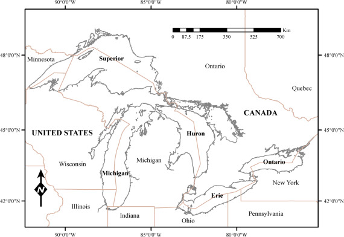

1. [Download: Download full-size image](https://ars.els-cdn.com/content/image/1-s2.0-S0308597X15000573-gr1.jpg)

Fig. 1. A map of the [Great Lakes region](https://www.sciencedirect.com/topics/earth-and-planetary-sciences/great-lakes-region). Countries are identified with bolded, capital font. States/provinces are identified with normal (non-bolded, non-capitalized) font. The lakes are identified with bolded, non-capitalized font. Map credit: Carolyn Foley, Illinois–Indiana Sea Grant College Program/Purdue University.

The [Great Lakes region](https://www.sciencedirect.com/topics/earth-and-planetary-sciences/great-lakes-region) has a long history of fishing with native/aboriginal communities engaging in fisheries since the beginning of human habitation in the area. [Commercial fisheries](https://www.sciencedirect.com/topics/earth-and-planetary-sciences/commercial-fishery) have existed in the region since European settlement of the area [5], [24] and are presently worth more than $22 million in dockside value annually ([25]). Recreational fishing has been documented in the area since the 1800s, and is a valuable economic resource for the region with an estimated impact of $393 million to $1.47 billion, or as high as $7 billion for the industry ([41], [2]). Along with this long history of extraction by humans comes a history of [resource depletion](https://www.sciencedirect.com/topics/earth-and-planetary-sciences/resource-depletion) and species extirpation. In fact, the annual catch of many species was already depleted by the end of the 19th century [5], [24].

Since the 1950s, many agencies and organizations have worked together to address the impacts that stem from human use of coastal areas, fish harvest and [invasive species](https://www.sciencedirect.com/topics/earth-and-planetary-sciences/invasive-species) on the Great Lakes [13]. These agencies range from local nongovernmental organizations located within the Great Lakes basin such as the Alliance for the Great Lakes and the Great Lakes Sport Fishing Council to political organizations such as the Council of Great Lakes Governors which is a collaboration of top politicians with the goal of working together on regional economic and resource management issues [24]. The Great Lakes recreational and commercial fisheries fall primarily within the jurisdictional boundaries of the eight states and one province rather than federal waters, and they are responsible for setting the conditions for stocking and harvesting [13].

Once highly contentious (see [14]), currently less so, Native Americans and the First Nations of Canada also maintain some rights to management of the Great Lakes fisheries. In the United States, fishing rights are based on several treaties reached between the U.S. government and Native American tribes. The Chippewa-Ottawa Treaty Fishery Management Authority and the Great Lakes Indian Fish and Wildlife Commission represent the tribes on various committees in the main fishery management organization, the Great Lakes Fishery Commission (GLFC: see further description of the GLFC in the next section). Canadian aboriginal people are also granted some off-reservation rights through the Canadian Constitution Act of 1982 [13]. The First Nations do not have a formal role in the GLFC, but instead, their fisheries are managed on their behalf by the province of Ontario [24].

### 1.2. Great Lakes Fishery Commission

Although no organization has singular responsibility for the valuable Great Lakes fishery, the GLFC serves as an umbrella organization for coordinating efforts of the complex multijurisdictional management arrangement. While the GLFC is specifically restricted from encroaching on the responsibilities of other federal, state and tribal agencies, it has been given responsibilities for the formulation and coordination of a research program for fish stocks and using the findings from the research program to make recommendations to the agencies involved [23]. The GLFC mainly functions under the Joint Strategic Plan for Management of Great Lakes Fisheries (GLFC 2007) which facilitates the Council of Great Lakes Fishery Agencies, the Council of Lake Committees, as well as the individual lake committees that are responsible for the research, monitoring and implementation of fisheries management for each of the five Great Lakes. The lake committees are particularly important for system-specific fisheries management and serve as a place for all levels of agencies to share research and discuss lake-specific issues. Each of these committees has at least one technical committee to provide scientific advice [24].

The GLFC functions at a binational, basin-wide coordinating level and through individual lake committees facilitates lake-specific management. In addition to the GLFC, agencies involved in the management of Great Lakes fisheries include the federal governments of the United States and Canada, two U.S. intertribal authorities (Chippewa-Ottawa Treaty Fishery Management Authority and the Great Lakes Indian Fish and Wildlife Commission), eight state governments (Minnesota, Wisconsin, Illinois, Indiana, Michigan, Ohio, Pennsylvania and New York), and the provincial government of Ontario [23]. Great Lakes fisheries management is also greatly influenced by stakeholder interests through the U.S. sportfishing, commercial fishing, public-at-large and agency advisors for each of the lake committees, and the Canadian public-at-large, sportfishing, commercial fishing, aboriginal community, environmental interests and academia advisors. In general, stakeholder participation is a key component for successful natural resource governance [44] and the GLFC advisors help facilitate that participation.

## 2. Network analysis in natural resource management

Researchers and managers are often interested in understanding how social relationships that compose complex governance structures, like that of the GLFC described above, hinder or promote good policies and practices [11], [19]. They are increasingly utilizing social network analysis to aid in this understanding [9], but the relationship between social networks and [natural resource management](https://www.sciencedirect.com/topics/earth-and-planetary-sciences/natural-resource-management) is just beginning to be understood and initial results present a complicated relationship. Tompkins and Adger [46] argued that [adaptive management](https://www.sciencedirect.com/topics/earth-and-planetary-sciences/adaptive-management) could expand social networks, therefore enhancing social resilience: the capacity for adaptation to various environmental stressors. Their argument is based on the idea that larger networks allow a wider decision-making environment in general and enhance the ability to cope with variability and decision making. The work of Bodin and Crona [4] as well as Bodin et al. [3] reveal that although it is clear that structure does make a difference in natural resource governance, there is no prescriptive mix of network characteristics for favorable governance.

One of the key uses for network analysis of natural resources (e.g. [3], [47], [4], [26]) and other fields (see [16] for a review) is for understanding the centrality of different types of nodes within a network. Centrality is the identification of key nodes that may be considered the “most important” within the social network [48]. Their importance stems from an increased ability to provide or solicit information from a large number of individuals or organizations [16]. The loss of a highly centralized node could also greatly impact information flow [31] and could disconnect peripheral nodes entirely from information flow within the network. In the case of the GLFC, in which there are a large number of organizations and agencies involved in decision making, the loss of nodes with high centrality could mean disruptions in communication among important groups.

Two important measures of centrality are degree and betweennness (see Fig. 2). For the study described herein of a nondirectional network, degree is “the number of nondirectional ties associated with a node” [37: 37]. In an affiliation network, degree can be used for the number of ties that an actor has with different organizations or for the number of ties that an organization has with different actors. For example, someone from the Ohio Department of Natural Resources may have formal and informal relationships with the Indiana Department of Natural Resources and the [Lake Erie](https://www.sciencedirect.com/topics/earth-and-planetary-sciences/lake-erie) Technical Committee. This indicates that the respondent has a degree of 2. We can also investigate the degree of an individual organization based on how many respondents identify that organization.

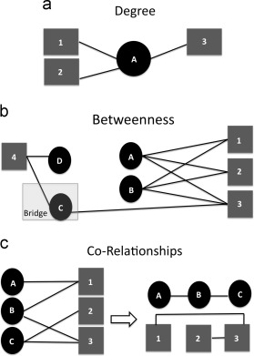

1. [Download: Download full-size image](https://ars.els-cdn.com/content/image/1-s2.0-S0308597X15000573-gr2.jpg)

Fig. 2. Measures applied to affiliation networks. The black circles represent actors, the grey squares represent organizations, and the numbers and letters are used to distinguish between the different actors/organizations. (a) Degree is a measure of the number of ties associated with a node; here the degree of actor *A*=3. (b) Betweenness is a measure of how connected a node is to nodes that are not connected to each other; here actor C bridges actor D and organization 4 with the other nodes, (c) Affiliation networks allow for the measurements of co-relationships; here actor A is connected to actor B because of their mutual connection to organization 1.

Bodin et al. [3] note that larger number of ties (higher degree) increase access to social memory, and reduce the impacts of the loss of an individual node. Social memory within natural resources governance is important because it is the collection of past experience that can be utilized in dealing with change, uncertainty or other problems. Increased connections to other nodes can also increase trust within an organization. Through increased possibilities of communication, higher degree can potentially increase mutual trust, thus facilitating [collective action](https://www.sciencedirect.com/topics/earth-and-planetary-sciences/collective-action) among different actors within a network [4]. While increased ties can benefit adaptive governance, adaptive capacity may be negatively affected because of increased political pressures felt by individuals. The more ties that a node has, the more likely that node will be locked into a position because of its responsibilities to all of the nodes with which it has ties [3], [21].

Brokerage is the understanding of the “participation in, and control of, information diffusion” [10: 353]. A common network measure for brokerage is betweenness centrality, another important centrality measure. Monge and Contractor [37] define betweenness centrality as “the extent to which a node is directly connected only to those other nodes that are not directly connected to each other.” Borgatti and Everett [6] note that in two-mode networks like affiliation networks, the paths that are used for calculating betweenness can be from a node in either mode (actors or organizations) to any other node (actors or organizations). For example, a commercial fishing advisor may be connected to commercial fishing organizations that no one else in the network is connected to, thereby serving an important bridging role between those groups and the rest of the network. Betweenness centrality can describe the amount of separation in groups within a network [3] and can also indicate bridges (also called brokers) who are “connecting otherwise disparate groups or nodes in the network” [26: 1064]. Because of their increased access to knowledge, bridges can find collaborative solutions to various environmental governance problems. They are very powerful within a network because of the control they have over the dissemination of information or resources between nodes [10], [39], [3]. In addition to these benefits, bridges have increased influence through the ability to negotiate deals between other nodes that are not connected to one another [31]. In the analysis of the northwest Atlantic herring and sea scallop fisheries management networks, [26] found that although there were low betweenness scores among managers in general, valuable bridges with very high betweenness scores connected the disparate groups and facilitated information transmission.

Folke et al. [20] note that successful governance and social transformations toward adaptive governance are often preceded by the emergence of informal networks that blur traditional lines of authority through the incorporation of diverse policy actors into the governance process. The networks help in the exchange of information, the identification of knowledge gaps and creation of nodes of expertise. Therefore, it is important to understand the relative importance of formal and informal relationships to help characterize network functioning [30], [1]. Informal relationships are “unsanctioned and ungoverned organic structures connecting a potentially unbound group of individuals” [1: 181]. These relationships can have different patterns of collaboration and communication than formal organizational relationships [12], [1]. Identifying informal relationships can reveal disconnections between organizations or individuals, unexpected key individuals who connect other organizations, and failures in enabling collaboration [1]. Although no work has been published for this in a fisheries context, in research to understand uplands management in the United Kingdom, Prell et al. [43] found that informal social networks have greater influence on stakeholders than formal organizational affiliation or stakeholder role.

## 3. Methods

To describe the GLFC policy and decision-makers network, a survey questionnaire was emailed to [fisheries policy](https://www.sciencedirect.com/topics/earth-and-planetary-sciences/fishery-policy) and decision makers affiliated with the GLFC using Qualtrics software. Two follow-up phone calls were made and two email reminders were sent to those who had not completed the survey. The network analysis questions were a part of a larger two-round Delphi-method survey conducted to understand information needs for the incorporation of climate change into Great Lakes fisheries management (for more information see [40]). The questions for the network analysis were only asked in the first round of the survey.

The list of names was acquired through a contact with the GLFC and was crosschecked with information available online for appointees and members of the GLFC. In this case, stakeholders were considered within the GLFC network, including federal, state and tribal fisheries managers and researchers, interested citizenry, and representatives from the commercial and recreational fishing communities. This type of affiliation network, also referred to as hypernetwork [34] or membership network, is a two-mode network in which one mode is a set of actors and the other mode is a set of events or organizations in which subsets of those actors participate [48]. Affiliation networks can be used to understand the number of organizations or events with which a set of actors has relationships. Additionally, sharing relationships with organizations increases the likelihood that the actors have a relationship or would develop ties [48].

Thus far, although there is an increasing interest in social network analysis in general, there has been very little research into affiliation networks in the natural resource governance literature, with the exception of Weible and Sabatier [49], Ward [47], and Smith [45]. These three research efforts utilized affiliation networks for diverse investigations: organizational affiliation to identify pro- and anti-MPA beliefs by types of organization, affiliation of nations participating in environmental treaties and intergovernmental organizations, and affiliation to intra-community informational networks in amenity-transition communities. The use of affiliation networks across these various topics of study highlights the usefulness of affiliation networks for a better understanding of natural resource governance.

There has also been little use of network analysis in understanding Laurentian Great Lakes fisheries governance, with the exception of Mueller et al. [38] and Leonard et al. [31]. Mueller et al.׳s [38] work focused specifically on charter fishing networks with a southeast Lake Michigan port. They found linkages among social capital, access to catch information, and average fish catch. In particular, those who were key communicators had catches that exceeded the average catch. Our work includes participation from the charter boat industry along with other stakeholders and fisheries policy and decision makers, but focuses more specifically on their role in stakeholder participation for managing the Great Lakes fishery. Our work also extends geographically to cover all five Great Lakes.

Leonard et al. [31] investigated the social network structure of the GLFC that has led to the perceived success of the Joint Strategic Plan (GLFC 2007) for efficient flow of information and the contributions of that network towards effective fisheries governance. Their research focused on participants in the committees responsible for implementing the plan and their ability to facilitate the exchange of information about general Great Lakes fish stocks and the more specific lake sturgeon stocks. They found 11 central individuals, but no significant reasons for why these individuals were central. They also found a number of bridges and a redundancy in those bridges, which implies that even with the loss of an individual bridge, the network would remain intact. Those bridges probably related to the even flow of information across the network. Our work has a different focus than Leonard et al. [31]; we focus on a broader understanding of the affiliation network of GLFC׳s policy and decision makers (henceforth, the actors) and their formal and/or informal relationships with public agencies and nonprofit organizations throughout the Great Lakes region (henceforth, the organizations). We also contribute to the understanding of the social network of the GLFC through an increased understanding of the importance of stakeholder involvement within the network and other roles within the GLFC.

The response rate for the survey was 69% (*n*=62) after accounting for bad addresses. Respondents included representatives from all state and provincial-level natural resource agencies; federal agencies from the United States and Canada; the Great Lakes Fishery Commission; tribal and aboriginal groups; and commercial fishing, sportfishing and public sector (including universities) organizations. Attaining the response rates that are called for in the social network literature (85%+) when researching natural resource governance is extremely difficult [26]. Within the natural resources social science literature, 80% response rates are extremely rare and are impractical in many contexts [26]. Our 69% response rate from a diverse group of respondents representing the diversity of jurisdictions and roles within the GLFC is justifiable in the social science literature, but there is a limitation in understanding the affiliation network of GLFC policy and decision makers.

Difficulties in identifying a clear boundary for the network contribute to response-rate limitations in natural resource governance research. The boundaries of involvement in [natural resource management](https://www.sciencedirect.com/topics/earth-and-planetary-sciences/natural-resource-management) are often blurry, even at a very localized level [26]. This research is even more challenged because it is an attempt to understand management at an ecosystem level and includes the policy and decision makers for the fisheries of five large lakes across a number of jurisdictional boundaries. Our resulting boundary for “decision and policy makers” is those who were identified by our contact at GLFC as GLFC “decision and policy makers” as well as any advisors formally designated to be a part of the GLFC lake committees and Council of Lake Committees. Defining a closed network of all organizations involved with Great Lakes fisheries at this scale is very difficult, if not impossible. Therefore, the context does not allow for the collection of a complete network dataset. For this research, we designed a network that identifies the formal and/or informal relationships of the policy and decision makers with organizations, but not the direct relationship between those organizations or between the respondents themselves.

An additional limitation that we found in our research is the protection of the confidentiality of respondents. Borgatti and Molina [8] identify a risk to research participants in network analysis of “the possibility of identifying individuals by combining collateral information” (p. 342). In fisheries management and other natural resource governance, there is often a small group of people who work together very closely and who could possibly be able to identify one another in network graphs or detailed descriptions even with names omitted. Maintaining their confidentiality is extremely important for the integrity of social science research, but it limits our ability to display findings in network graphs and to discuss findings publicly. This is one reason why we chose to investigate the affiliation network at an organizational level rather than at an individual level.

For this research, in order to maintain confidentiality of respondents, the respondents were grouped together by role within the GLFC in all figures and descriptions. These roles were divided into official representation as a part of the GLFC as a commissioner or GLFC staff; an official representative to one of the lake committees as an agency, commercial fishing, sportfishing, or public sector representative; or as someone who was identified as playing a critical role in GLFC policy and decision making through their affiliation with a federal, tribal/aboriginal, or state/provincial organization (see Table 1).

Table 1. Different types of respondents, the number of each type of respondent, and their average degree and betweenness scores. The average degree and average betweenness scores were calculated by summing the degrees/betweenness centrality scores of each respondent within a respondent type and dividing by the total number of respondents of that type. The average degree of GLFC staff, federal agency representatives and state/provincial agency advisors to the lake committees are statistically different from the commercial fishing advisors and sportfishing advisors to the lakes committees (*p*<0.05); no other differences in degree or betweenness are statistically significant.

| Respondents | Average degree | Degree range | Average betweenness | Betweenness range |
| --- | --- | --- | --- | --- |
| GLFC Staff (*n*=4) | 43.8 | 41–45 | 0.017 | 0.009–0.023 |
| Federal agency (*n*=7) | 36.7 | 9–46 | 0.021 | 0.000–0.055 |
| State/provincial agency advisor to GLFC (*n*=10) | 32.3 | 14–45 | 0.038 | 0.001–0.077 |
| State/provincial agency (*n*=10) | 25 | 11–46 | 0.014 | 0.000–0.038 |
| GLFC commissioner (*n*=2) | 22.5 | 8–37 | 0.009 | 0.000–0.017 |
| Public sector advisor to GLFC (*n*=8) | 21.9 | 7–45 | 0.013 | 0.000–0.032 |
| Tribal/aboriginal agency to GLFC (*n*=3) | 18.0 | 5–31 | 0.002 | 0.000–0.004 |
| Commercial fishing advisor to GLFC (*n*=8) | 13.8 | 2–35 | 0.014 | 0.000–0.030 |
| Sportfish advisor to GLFC (*n*=10) | 13.2 | 3–36 | 0.022 | 0.001–0.061 |
| Overall average | 24.5 | 2–46 | 0.019 | 0.000–0.077 |

Respondents were asked to identify whether they had a formal or an informal relationship with the organizations. Formal relationships were defined as, “other organizations you formally report to, collaborate or work with on Great Lakes fisheries management (e.g. you work for the DNR, but you are partially assigned to the U.S. FWS; other agencies with whom you have worked on grants).” Informal relationships were defined as, “other agencies/organizations that you have an informal professional relationship with (e.g. which agency/organization has professionals that you would call if you had a Great Lakes fisheries management question?).”

Hartley [26] noted that although there are a number of ways to identify ties (e.g. frequency of contact – daily, weekly, etc.; strength of relationship – weak to strong; etc.), there are challenges to capturing true influence and information flow. Moreover, in capturing these differences, there are concerns of survey fatigue. Survey fatigue is loss of interest in a study because of high respondent burden through an excess of questions or complex questions [42]. Because the focus of this research was at the organizational level, we used formal and informal relationships as the different types of ties for our study. Unless otherwise noted, the formal/informal relationships are merged in the analyses.

UCINET 6 software was used for network analysis [7]. Betweenness centrality for both the actors and the organizations was calculated using the two-mode centrality measures function of UCINET.

## 4. Results and discussion

The results reveal a complex network where 62 GLFC policy and decision makers have informal or formal relationships with 149 identified organizations through 1516 ties (see Fig. 3 for an illustration of the network). The breadth of organizations involved includes government agencies across federal and state/provincial lines, a large number of Great Lakes environmental governance organizations, and a large number of stakeholder and universities and research organizations. A wide network such as this may allow for more individuals or groups to influence decision making [46], and provides opportunities for soliciting feedback and accepting research or ideas from those organizations as well as for providing information back to those groups.

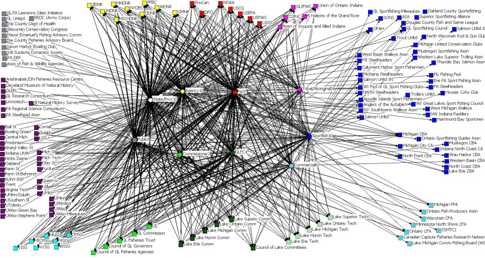

1. [Download: Download full-size image](https://ars.els-cdn.com/content/image/1-s2.0-S0308597X15000573-gr3.jpg)

Fig. 3. The complex affiliation network graph of the GLFC׳s decision and policy makers. The circles are the actors and the colors of the circles indicate different roles within the GLFC. The respondents׳ roles are labeled along with the number of respondents of that type. The colors for the actors (going clockwise by cluster, starting top left for those reading the article in grayscale) represent the following: white-state/provincial agency participant who is not an official advisor to the GLFC or its committees, yellow-state/provincial agency official advisor to the GLFC or its committees, red-federal agency participant, pink- tribal/aboriginal participant, royal blue-sportfish advisor, light blue-commercial fishing advisor, dark green-GLFC staff, and bright green-GLFC commissioner, and grey-public sector advisor. The squares represent the identified organizations and the colors of the squares indicate different types of organizations. The colors (going clockwise by cluster, starting top left for those reading the article in grayscale) represent the following: grey-non-governmental organizations, yellow-state or provincial agency with fisheries responsibilities, red-U.S. or Canadian federal agency, pink-First Nations or Native American government or agency, royal blue-recreational fishing (upper cluster group) or charter boat organization (lower cluster group), light blue-commercial fishing organization, seafoam green-technical committees of the GLFC, dark green-GLFC committees, bright green-Great Lakes governance organizations, turquoise-Sea Grant College Programs, and dark purple-universities (lower cluster group) or research institutions (upper cluster group). These colors and placement are consistent throughout this paper. (For interpretation of the references to color in this figure legend, the reader is referred to the web version of this article.)

In addition to the direct relationships between the actors (i.e., respondents, who constitute GLFC policy and decision makers) and the organizations, co-relationships increase the likelihood of ties between the actors or between the organizations [17], [43]. The affiliation matrix of actors indicated an average identification of co-relationships with 11.5 organizations. This means that on average, the number of organizations with which each respondent shared a relationship with another respondent was 11.5. These shared relationships are important because they can potentially foster communication between the diverse groups of involved stakeholders and resource managers representing public interests, commercial and recreational fishing interests, and federal and state natural resource management agencies. The largest number of shared organizations was 45 between two federal agency affiliates and the smallest number of shared organizations was 0 between 108 of the respondent pairs. Out of the GLFC role groupings, the sportfishing representatives had the highest number of no co-relationships.

The affiliation matrix of the 149 organizations (Fig. 3) indicated an average identification of co-relationships between the organizations of 2.2. This means that the average number of actors any pair of organizations shares is 2.2. The largest number of shared policy and decision makers was 42 between the U.S. Geological Survey (USGS) and the U.S. Fish and Wildlife Service (USFWS). This indicates a higher likelihood of social ties between the two organizations and an increased ability for communication across the two agencies. In the affiliation network, 6712 of the organization pairs did not share relationships with the policy and decision makers. As expected because of the nature of the survey questions, the free recall organizations were more likely than the listed organizations to not share relationships with policy and decision makers with other organizations.

In summary, with the methodological constraint of maintaining respondent confidentiality, the co-relationships identified through affiliation networks are one way of understanding the strength of social ties among Great Lakes fisheries decision and policy makers. The results, with an average of 11.5 shared organizations between any two actors and an average of 2.2 shared relationships between any two organizations, show a network that allows for an increased likelihood for relationships among the organizations and among the actors. These co-relationships can be beneficial in a fisheries management context for sharing data and institutional knowledge while reducing redundancy of efforts across the different organizations or actors.

### 4.1. Formal and informal ties

As discussed in Section 2, Folke et al. [20] note that informal networks that incorporate diverse policy actors play an important role in [adaptive management](https://www.sciencedirect.com/topics/earth-and-planetary-sciences/adaptive-management). The results show that informal relationships also play an important role with 696 out of the total 1516 identified ties (46%) identified as informal-only ties. An additional 42 actors identified both formal and informal relationships with the same organization. Additionally, 23 organizations were identified through informal relationships only (see Fig. 4). Only one of the organizations in the fixed roster, an aboriginal group (the 6 Nations of the Grand River), was not recognized by any of the respondents as an organization with which they had a formal relationship. All of the other organizations that were only recognized through informal relationships were identified in the free recall questions.

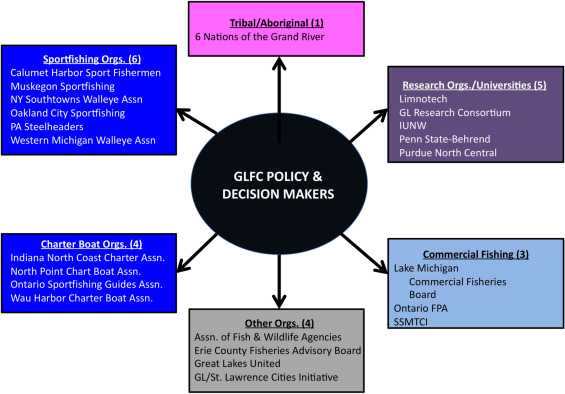

1. [Download: Download full-size image](https://ars.els-cdn.com/content/image/1-s2.0-S0308597X15000573-gr4.jpg)

These informal relationship ties can facilitate a number of relationships beyond the formal inter-jurisdictional relationships. These informal relationships can be formed through a number of settings including studying at the same university or maintaining relationships with colleagues if they move to other organizations. In past analyses of social networks in natural resources governance, there has been an emphasis on documenting formal relationships (participation in a process, specific agreements between managers, etc.). The sheer number of informal ties in Great Lakes fisheries management provides an important lesson that informal relationships also play a critical role in natural resources governance, and not including the informal ties may unintentionally overlook some organizations or individuals that play important roles in governance. For example, Prell et al. [43] found that many views are strongly influenced by informal interactions and recommend carefully identifying stakeholders to engage in issues. Additionally, in the private sector, informal networks have been described as critical for cross-functional projects and collaborations and innovation [12].

### 4.2. Actor analysis

The average number of organizations with which a GLFC decision and policy maker has formal/informal relationship is 24.5 (range 2–46). The roles that identified the largest average numbers of formal/informal relationships (the highest degree) were the GLFC staff, federal agency affiliates, and state/provincial agency advisors to the GLFC (see Table 1). These three roles had degrees that were significantly higher than the commercial fishing and recreational fishing advisors, but these were the only statistically significant differences in degree for the network (see Table 1). The respondents with high degree may be important in environmental governance and, in this case, the GLFC staff, federal agency representatives, and state/provincial advisors to the lake committees may serve critical roles in Great Lakes fisheries management. Specifically, actors with high degree within the affiliation network indicate policy and decision makers with ties to a large number of organizations which can protect the institutional memory of GLFC and facilitate communication across a large number of organizations.

As discussed earlier, Newman and Dale [39] argued that not all networks are the same, so it is important to look at the structures of each network. In our affiliation network, we found important bridging roles for several groups, including the sportfishing advisors to the GLFC. Although the sportfishing advisors to the lake committees do not have a statistically different betweenness score from any of the other roles, the sportfishing advisors have the second highest average betweenness despite having the lowest average degree (which is statistically significantly lower than the GLFC staff, agency advisors, and federal agency representatives). This relatively higher betweenness score indicates an important bridging role. As shown in Fig. 5, sportfishing advisors identified relationships with 18 organizations with which no other respondents identified a relationship. This indicates that although the sportfishing advisors identified fewer average relationships with organizations in the affiliation network, they still play an important bridging role to the 18 identified organizations, including 14 sportfishing and charter boat organizations that would otherwise be isolates in the network.

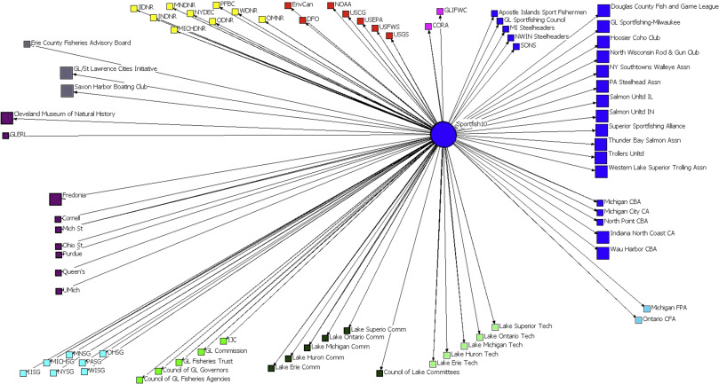

1. [Download: Download full-size image](https://ars.els-cdn.com/content/image/1-s2.0-S0308597X15000573-gr5.jpg)

Fig. 5. Affiliation network graph for sportfishing advisors to the GLFC. The blue circle in the center represents the ten sportfishing-advisor respondents. The squares represent organizations with ties to the ten sportfishing advisors and the different colors represent different types of organizations. The larger squares represent organizations identified by the sportfishing advisors to the GLFC, but not by any other type of respondent (role in the GLFC) in the network. (For interpretation of the references to color in this figure legend, the reader is referred to the web version of this article.)

Actors identified as commercial fishing advisors to lake committees were also characterized by statistically lower average degree than the GLFC staff, agency advisors, and federal agency representatives. Although their betweenness index was not statistically different from any other roles in the network, they still appear to play an important bridging role in the network (see Fig. 6). Eight of the identified organizations would be isolates if not for the commercial fishing advisors including three commercial fishing organizations, two charter boat associations and one each of the sportfishing, other and university/research organizations. In Great Lakes fisheries, these fishing advisors are sometimes the only connections to many of the commercial and sportfishing groups, and therefore could have increased influence in information dissemination/collection.

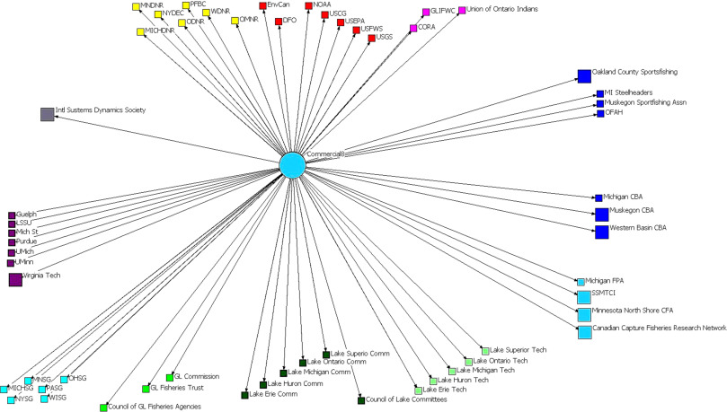

1. [Download: Download full-size image](https://ars.els-cdn.com/content/image/1-s2.0-S0308597X15000573-gr6.jpg)

In addition to the important bridging roles of commercial and sport fishing advisors to the lake committees, the state/provincial agencies play important roles. As shown in Fig. 7, the state/provincial appointed advisors to the lake committees and the other state/provincial fisheries management agency professionals who are GLFC policy and decision makers account for 573 ties in the affiliation network (more than 1/3 of the total 1516 ties). Additionally, the organizations had the second highest average degree and betweenness indices out of any organization type. The state/provincial advisors to the lake committees had the highest average betweenness and the third highest degree of all respondent types. Without these advisors, 23 organizations would be isolates in the network including three “other” organizations, ten research organizations/universities, nine sportfishing organizations and one charter boat association. In addition to the contributions to the network from the agency advisors to the lake committees, the other respondents affiliated with the state/provincial fisheries management agencies also play important roles in the GLFC. Without their role in the GLFC, seven organizations would be isolates.

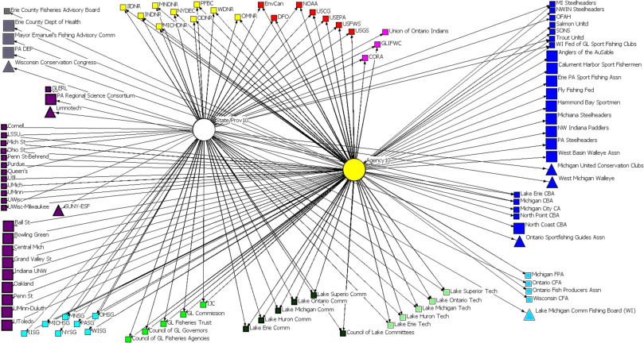

1. [Download: Download full-size image](https://ars.els-cdn.com/content/image/1-s2.0-S0308597X15000573-gr7.jpg)

Fig. 7. Affiliation network graph for state/provincial agencies. The graph includes advisors to the GLFC lake committees (labeled “Agency” on graph) and other state/provincial fisheries management agency professionals who are GLFC decision and policy makers (labeled “State/Prov” on graph). The yellow circle represents ten agency advisors to the GLFC lake committees. The cream circle represents ten state/agency professionals who are GLFC policy/decision makers, but who are not an agency advisor to a GLFC lake committee. The squares represent organizations with which these respondents have ties. The larger squares represent organizations identified only by the state/provincial agency advisors to the lake committees. The triangles represent organizations identified only by the decision and policy makers from state/provincial agencies who are not advisors to the lake committees. (For interpretation of the references to color in this figure legend, the reader is referred to the web version of this article.)

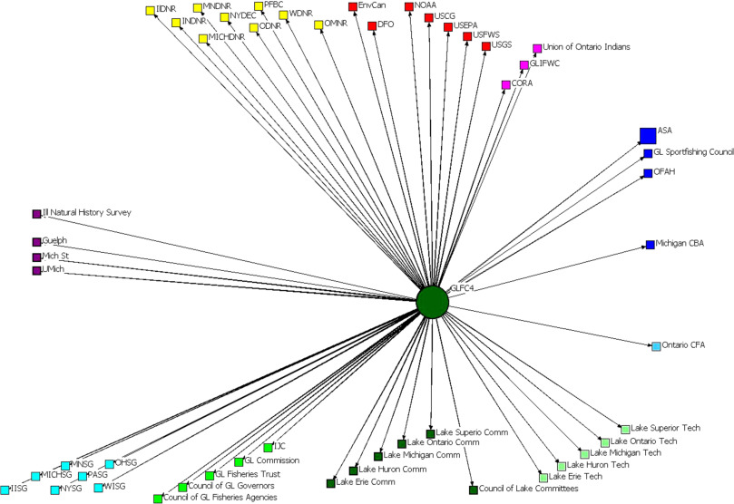

1. [Download: Download full-size image](https://ars.els-cdn.com/content/image/1-s2.0-S0308597X15000573-gr8.jpg)

Fig. 8. Affiliation network graph for the GLFC staff members׳ formal/informal relationship with organizations. The green circle in the center represents the four GLFC staff respondents. The squares represent organizations with ties to the four GLFC staff respondents and the different colors represent different types of organizations. As marked by the larger box, the ASA, the American Sportfishing Association, is the only organization that would be an isolate without the GLFC staff. (For interpretation of the references to color in this figure legend, the reader is referred to the web version of this article.)

### 4.3. Organization analysis

As shown in Table 2, the organizations had an average degree of 10.3 (range 1–47). The organizations listed in the questionnaire had an overall average degree of 29.8 (range 2–47) and the free recall organizations had an overall average of 1.9 (range 1–19). The overall average betweenness score was 0.005 (range 0–0.054) with an average betweenness score of 0.017 (range 0.000–0.054) for listed organizations and 0.0002 (range 0–0.009) for organizations identified through free recall.

Table 2. Different types of organizations that were identified by the respondents, the number of each type of organization, and their average degree and betweenness scores. Organization types cannot be statistically compared because of the differences in identification (organizations identified from a list vs. freely recalled organizations).

| Empty Cell | Identified organization type (total *n*=149) | Average degree | Degree range | Average betweenness | Betweenness range |
| --- | --- | --- | --- | --- | --- |
| Listed organizations | Federal agency (U.S. and Canadian) (7) | 37.4 | 30–47 | 0.026 | 0.011–0.054 |
|  | State/provincial fisheries agencies (9) | 37.4 | 32–45 | 0.022 | 0.011–0.041 |
|  | Tribal/aboriginal-fisheries agencies-GLFC members (2) | 33.5 | 33–34 | 0.019 | 0.019–0.020 |
|  | GLFC component (11) | 31.2 | 22–38 | 0.020 | 0.006–0.045 |
|  | Great lakes organizations (5) | 29 | 24–34 | 0.011 | 0.006–0.017 |
|  | Sea grant (7) | 22 | 16–37 | 0.009 | 0.002–0.025 |
|  | Tribal/aboriginal fisheries agencies-non-GLFC members (3) | 5 | 2–9 | 0.000 | 0.000–0.001 |
|  | Listed average | 29.8 | 2–47 | 0.017 | 0.000–0.054 |
| Free recall orgs. | Commercial fishing (8) | 2.7 | 1–7 | 0.000 | 0.000–0.001 |
|  | Universities/research (39) | 2.3 | 1–19 | 0.000 | 0.000–0.009 |
|  | Charter boat (10) | 2 | 1–9 | 0.000 | 0.000–0.002 |
|  | Sportfishing (36) | 1.6 | 1–7 | 0.000 | 0.000–0.001 |
|  | Other (11) | 1.1 | 1–2 | 0.000 | 0.000–0.000 |
|  | Free recall average | 1.9 | 1–19 | 0.0002 | 0.000–0.009 |
|  | Overall average | 10.3 | 1–47 | 0.005 | 0.000–0.054 |

The organizations with the highest degree were federal and state/provincial agencies. This is not surprising given that many of the respondents are a part of these organizations and these agencies have official roles in the GLFC. Federal agencies may have a higher degree than state agencies as a matter of geography; the federal agencies have responsibilities to all of the Great Lakes, but each lake is managed only by its bordering states. The federal agencies had an average degree of 37.4 and the highest degrees were the U.S. Fish and Wildlife Service (USFWS: 47), U.S. Geological Service (USGS: 43), and the Canadian Department of Fisheries and Oceans (DFO: 41). State/provincial agencies also had a degree average of 37.4 and the highest degrees were the Michigan Department of Natural Resources (Michigan DNR: 45), Ontario Ministry of Natural Resources (OMNR: 42), and the Wisconsin Department of Natural Resources (WDNR: 39). The tribal organizations that are members of the GLFC along with the state/provincial agencies had the third highest degree with the Chippewa-Ottawa Research Authority having a degree of 34 and the Great Lakes Indian Fish and Wildlife Commission having a degree of 33.

Not surprisingly, many of the organizations with the highest degree indices also had high betweenness, but there were a few differences reflecting the jurisdiction of the various agencies with sometimes less integrated stakeholders. The federal agencies also had the highest betweenness with a betweenness of 0.0542 for the USFWS, 0.039 for the USGS and 0.0267 for the DFO. The Michigan Department of Natural Resources had the highest betweenness score of any state agency and the second highest overall betweenness score of 0.0407. The NY Department of Environmental Conservation (NYDEC) had the second highest betweenness score (0.0347) despite having the fourth highest degree out of the state/provincial agencies. The NYDEC likely has a lower degree than the other state/provincial agencies because NYDEC has no jurisdiction over [Lakes Superior](https://www.sciencedirect.com/topics/earth-and-planetary-sciences/lake-superior), Huron, or Michigan. This increased betweenness score stems from its governance over Lake Ontario which has fewer agencies responsible for its management, therefore increasing the importance of the agencies that are involved. The Ontario Ministry of Natural Resources (OMNR), the other state or provincial agency involved with Lake Ontario fisheries management, had the third greatest betweenness score of 0.0285. OMNR likely had a high degree because it has jurisdiction over all five of the Great Lakes.

In particular, the respondents indicated a large number of universities and research institutions and fishing stakeholder groups with which they have formal and informal relationships. The ties to universities and research institutions indicate possibilities for research collaborations to investigate concerns of the GLFC with regard to the Great [Lakes ecosystem](https://www.sciencedirect.com/topics/earth-and-planetary-sciences/lake-ecosystem) and also for those institutions to use their research to influence fisheries governance. The large numbers of commercial and sportfishing organizations identified by the respondents show the possible influence of stakeholders on management as well as the ability for the GLFC to solicit information, feedback and/or support from a large number of anglers and commercial fishers.

## 5. Conclusion

Overall, the policy and decision maker affiliation network shows the importance of the different roles within the GLFC and Great Lakes fisheries management. Gaden et al. [23] outlined three pillars of Great Lakes fisheries management, namely, (1) provincial, state and U.S. tribal management authority, (2) federal capability, and (3) bi-national responsibilities through the GLFC. Although this research specifically targeted decision and policy makers of the GLFC, the importance of all three pillars is shown through the affiliation network analysis. This research included representatives from the state and provincial agencies who play both official (appointed roles as agency advisors to the lake committees) and unofficial decision and policy maker roles in the GLFC. Combined, these respondents accounted for more than one-third of the identified formal and/or informal relationships and if not for their inclusion, 30 organizations would not have been connected to the affiliation network of GLFC policy and decision makers (see Fig. 7).

While the federal agency policy and decision makers do not have official advisory roles in the lake committees or to the GLFC, the federal agencies play important supporting roles in Great Lakes fisheries management [23]. For example, the Canadian and U.S. federal agencies had the highest average degree and one federal agency, the U.S. Fish and Wildlife Service, had the highest degree of any organization. This means that those organizations were identified by the most respondents through formal or informal relationships. Additionally, the federal agency respondents had the second highest average degree and the third highest average betweenness, which indicates both a high number of relationships as well as ties to organizations that may not otherwise be incorporated into management.

When looking at the GLFC, including its staff and stakeholder advisors, we find many important roles within its structure. GLFC staff had the highest average degree scores (statistically higher than the commercial and sport fishing advisors), but lower average betweenness scores. This reflects their role in coordinating the specific committees and agencies involved with Great Lakes fisheries, but not necessarily for coordinating the activities of stakeholders. The fishing stakeholder advisors had fewer identified relationships, but serve as critical links to those stakeholder groups that may not otherwise be engaged.

In revisiting the research questions, we find that the GLFC decision and policy makers׳ network is quite large and that many of the respondents share formal or informal relationships with the same organizations. Many of the organizations also share relationships with the same decision and policy makers. The sheer number of organizations influencing the decision and policy makers as well as the relationships among them indicates a network that provides opportunities for information dissemination and collection, but that could also be a hindrance because of its large organizational numbers. For example, different stakeholder organizations may have opposing objectives, so increasing the numbers of involved organizations could increase the possibility for conflict or bureaucratic limitations.

This network analysis methodology was limited by several characteristics of the data. First, as discussed earlier, concerns about confidentiality led to the inability to show the networks at the actor level or qualitatively describe important actors. If similar research were to be conducted without needing to accommodate confidentiality, more robust descriptions of the networks and key actors could be provided. Second, this analysis is limited by the use of listed and free-recall questions. This research is the first step in understanding the breadth of the organizations involved with Great Lakes fisheries management so the number of organizations was unknown *a priori* making a full list impossible. This, in combination with the lack of a clear network boundary, limited the centrality measures that could be used as well as a number of other network measures. The identified affiliation network could be used in future research, but with the caveat that it represents the formal and/or informal relationships of only those who responded to the survey, which is 69% of the total identified GLFC decision and policy makers.

This research contributes to the understanding of social network analysis in natural resource governance through its usage of affiliation networks at an ecosystem level. Specifically, the use of affiliation networks allowed for better understanding of the network and key roles within the GLFC without sacrificing the confidentiality of respondents. The use of affiliation networks also enabled a furthered understanding of the breadth of relationships that form the Great Lakes fisheries management decision and policy maker network at an ecosystem-wide scale. Additionally, this research improves the understanding of natural resource governance networks through its examination of both formal and informal ties. Informal ties play a considerable role in the GLFC decision and policy maker network, and the use of only formal relationships should be considered carefully when trying to understand environmental governance.

Understanding the affiliation network of a large, binational organization׳s policy and decision makers is one step towards a broader knowledge of the complexities of stakeholder involvement, the breadth of involvement/interest by organizations, and the challenges/benefits created by such complex networks for information collection and dissemination.

## Acknowledgments

The research for this paper was funded by the National Oceanic and Atmospheric Administration׳s Sector Applications Research Grant number NA10OAR4310147 and Purdue University׳s Department of Forestry and Natural Resources. The authors would like to thank the Great Lakes managers who participated in the surveys, and are grateful to the Great Lakes Fishery Commission for their assistance. The Purdue University Natural Resources Social Science Lab, Purdue University Fisheries Ecology Lab, and the other researchers on this grant, especially Carolyn Foley, also provided invaluable assistance for the development of this work. We are also grateful to anonymous reviewers of this work who provided valuables edits to this work.

## References

1. [1]

   J. Allen, A.D. James, P. Gamlen

   Formal versus informal knowledge networks in R&D: a case study using social network analysis

   R&D Manag, 37 (2007), pp. 179-196

   [View at publisher](https://doi.org/10.1111/j.1467-9310.2007.00468.x)[Crossref](https://doi.org/10.1111/j.1467-9310.2007.00468.x)[View in Scopus](https://www.scopus.com/inward/record.url?eid=2-s2.0-34250017706&partnerID=10&rel=R3.0.0)Google Scholar
2. [2]

   ASA (American Sportfishing Association). Sportfishing in America: an economic force for conservation. A report of the American Sportfishing Association; 2013.

   Google Scholar
3. [3]

   O. Bodin, B. Crona, H. Ernstson

   Social networks in natural resource management: what is there to learn from a structural perspective

   Ecol Soc, 11 (2) (2006), p. 2

   Google Scholar
4. [4]

   O. Bodin, B.I. Crona

   The role of social networks in natural resource governance: what relational patterns make a difference

   Glob Environ Change, 19 (2009), pp. 366-374

   [View in Scopus](https://www.scopus.com/inward/record.url?eid=2-s2.0-67650741405&partnerID=10&rel=R3.0.0)Google Scholar
5. [5]

   M.B. Bogue

   Fishing the Great Lakes: an environmental history

   University of Wisconsin Press, Madison (2000), pp. 1783-1933

   [Google Scholar](https://scholar.google.com/scholar_lookup?title=Fishing%20the%20Great%20Lakes%3A%20an%20environmental%20history&publication_year=2000&author=M.B.%20Bogue)
6. [6]

   S.P. Borgatti, M.G. Everett

   Network analysis of 2-mode data

   Soc Netw, 19 (1997), pp. 243-269

   [View in Scopus](https://www.scopus.com/inward/record.url?eid=2-s2.0-0031206353&partnerID=10&rel=R3.0.0)[Google Scholar](https://scholar.google.com/scholar_lookup?title=Network%20analysis%20of%202-mode%20data&publication_year=1997&author=S.P.%20Borgatti&author=M.G.%20Everett)
7. [7]

   S.P. Borgatti, M.G. Everett, L.C. Freeman

   UCINET for windows: software for social network analysis

   Analytic Technologies, Harvard, MA (2002)

   Google Scholar
8. [8]

   S.P. Borgatti, J.L. Molina

   Ethical and strategic issues in organizational social network analysis

   J Appl Behav Sci, 39 (3) (2003), pp. 337-349

   [View in Scopus](https://www.scopus.com/inward/record.url?eid=2-s2.0-17044395255&partnerID=10&rel=R3.0.0)[Google Scholar](https://scholar.google.com/scholar_lookup?title=Ethical%20and%20strategic%20issues%20in%20organizational%20social%20network%20analysis&publication_year=2003&author=S.P.%20Borgatti&author=J.L.%20Molina)
9. [9]

   S.P. Borgatti, A. Mehra, D.J. Brass, G. Labianca

   Network analysis in the social sciences

   Science, 323 (2009), pp. 892-895

   [View at publisher](https://doi.org/10.1126/science.1165821)[Crossref](https://doi.org/10.1126/science.1165821)[View in Scopus](https://www.scopus.com/inward/record.url?eid=2-s2.0-60149086627&partnerID=10&rel=R3.0.0)[Google Scholar](https://scholar.google.com/scholar_lookup?title=Network%20analysis%20in%20the%20social%20sciences&publication_year=2009&author=S.P.%20Borgatti&author=A.%20Mehra&author=D.J.%20Brass&author=G.%20Labianca)
10. [10]

    R.S. Burt

    The network structure of social capital

    Res Organ Behav, 22 (2000), pp. 345-423

    [View in Scopus](https://www.scopus.com/inward/record.url?eid=2-s2.0-35448990973&partnerID=10&rel=R3.0.0)[Google Scholar](https://scholar.google.com/scholar_lookup?title=The%20network%20structure%20of%20social%20capital&publication_year=2000&author=R.S.%20Burt)
11. [11]

    B. Crona, K. Hubacek

    The right connections: how do social networks lubricate the machinery of natural resource governance

    Ecol Soc, 15 (4) (2010), p. 18

    Google Scholar
12. [12]

    R. Cross, N. Nohria, A. Parker

    Six myths about informal networks and how to overcome them

    MIT Sloan Manag Rev, 43 (2002), pp. 67-75

    [View in Scopus](https://www.scopus.com/inward/record.url?eid=2-s2.0-0039490151&partnerID=10&rel=R3.0.0)[Google Scholar](https://scholar.google.com/scholar_lookup?title=Six%20myths%20about%20informal%20networks%20and%20how%20to%20overcome%20them&publication_year=2002&author=R.%20Cross&author=N.%20Nohria&author=A.%20Parker)
13. [13]

    M.R. Dochoda

    C.4 Authorities, responsibilities, and arrangements for managing fish and fisheries in the Great Lakes ecosystem

    W.W. Taylor, C.P. Ferreri (Eds.), Great Lakes Fishery Policy and Management: A Binational Perspective, Michigan State University Press, East Lansing, MI (1999), pp. 93-112

    Google Scholar
14. [14]

    R. Doherty

    Disputed waters: Native Americans and the Great Lakes Fishery

    University Press of Kentucky, Lexington (1990)

    [Google Scholar](https://scholar.google.com/scholar_lookup?title=Disputed%20waters%3A%20Native%20Americans%20and%20the%20Great%20Lakes%20Fishery&publication_year=1990&author=R.%20Doherty)
15. [15]

    C.N. Ehler

    Indicators to measure governance performance in integrated coastal management

    Ocean Coast Manag, 46 (2003), pp. 335-345

    [View in Scopus](https://www.scopus.com/inward/record.url?eid=2-s2.0-0038702074&partnerID=10&rel=R3.0.0)[Google Scholar](https://scholar.google.com/scholar_lookup?title=Indicators%20to%20measure%20governance%20performance%20in%20integrated%20coastal%20management&publication_year=2003&author=C.N.%20Ehler)
16. [16]

    K. Faust

    Centrality in affiliation networks

    Soc Netw, 19 (1997), pp. 157-191

    [View in Scopus](https://www.scopus.com/inward/record.url?eid=2-s2.0-0031116726&partnerID=10&rel=R3.0.0)[Google Scholar](https://scholar.google.com/scholar_lookup?title=Centrality%20in%20affiliation%20networks&publication_year=1997&author=K.%20Faust)
17. [17]

    S.L. Feld

    The focused organization of social ties

    Am J Sociol, 86 (1981), pp. 1015-1035

    [Google Scholar](https://scholar.google.com/scholar_lookup?title=The%20focused%20organization%20of%20social%20ties&publication_year=1981&author=S.L.%20Feld)
18. [18]

    S. Field, K.A. Frank, K. Schiller, C. Riegle-Crumb, C. Muller

    Identifying positions from affiliation networks: preserving the duality of people and events

    Soc Netw, 28 (2006), pp. 97-123

    [View in Scopus](https://www.scopus.com/inward/record.url?eid=2-s2.0-32544437794&partnerID=10&rel=R3.0.0)Google Scholar
19. [19]

    B. Fisher

    Social networks: their role in fisheries

    Fisheries, 37 (2012)

    243–243

    [Google Scholar](https://scholar.google.com/scholar_lookup?title=Social%20networks%3A%20their%20role%20in%20fisheries&publication_year=2012&author=B.%20Fisher)
20. [20]

    C. Folke, T. Hahn, P. Olsson, J. Norberg

    Adaptive governance of social-ecological systems

    Annu Rev Environ Resour, 30 (2005), pp. 441-473

    [View at publisher](https://doi.org/10.1146/annurev.energy.30.050504.144511)[Crossref](https://doi.org/10.1146/annurev.energy.30.050504.144511)[View in Scopus](https://www.scopus.com/inward/record.url?eid=2-s2.0-28644446336&partnerID=10&rel=R3.0.0)[Google Scholar](https://scholar.google.com/scholar_lookup?title=Adaptive%20governance%20of%20social-ecological%20systems&publication_year=2005&author=C.%20Folke&author=T.%20Hahn&author=P.%20Olsson&author=J.%20Norberg)
21. [21]

    K.A. Frank, J.Y. Yasumoto

    Linking action to social structure within a system: social capital within and between subgroups

    Am J Sociol, 104 (1998), pp. 642-686

    [View in Scopus](https://www.scopus.com/inward/record.url?eid=2-s2.0-0032238581&partnerID=10&rel=R3.0.0)Google Scholar
22. [22]

    J.A. Frank, K. Mueller, A. Krause, W.W. Taylor, Taylor, N.J. Leonard

    The intersection of global trade, social networks and fisheries

    W.W. Taylor, M.G. Schecter, J.G. Wolfson (Eds.), Globalization: effects on fisheries resources, Cambridge University, New York, NY, USA (2007), pp. 385-423

    [View in Scopus](https://www.scopus.com/inward/record.url?eid=2-s2.0-34247106714&partnerID=10&rel=R3.0.0)Google Scholar
23. [23]

    M. Gaden, C. Krueger, C. Goddard, G. Barnhart

    A joint strategic plan for management of great lakes fisheries: a cooperative regime in a multi-jurisdictional setting

    AquatEcosyst. Health Manag, 11 (2008), pp. 50-60

    [View at publisher](https://doi.org/10.1080/14634980701877043)[Crossref](https://doi.org/10.1080/14634980701877043)[View in Scopus](https://www.scopus.com/inward/record.url?eid=2-s2.0-40349105872&partnerID=10&rel=R3.0.0)Google Scholar
24. [24]

    M. Gaden, C. Krueger

    C. 7 Multi-jurisdictional governance of the Great Lakes Fishery: can a nonbinding agreement work

    S. Brooks, B.G. Rabe. (Eds.), Environmental governance on the 49th parallel: new century, new approaches, Woodrow Wilson Center for International Scholars, Washington, DC (2009)

    Google Scholar
25. [25]

    GLMRIS (Great Lakes and Mississippi River Interbasin Study). Commercial fisheries baseline economic assessment – U.S. waters of the Great Lakes, Upper Mississippi River, Ohio River basins; 2012. 92 p.

    Google Scholar
26. [26]

    T.W. Hartley

    Fishery management as a governance network: examples from the Gulf of Maine and the potential for communication network analysis in fisheries

    Mar Policy, 34 (2010), pp. 1060-1067

    [View in Scopus](https://www.scopus.com/inward/record.url?eid=2-s2.0-77952981435&partnerID=10&rel=R3.0.0)Google Scholar
27. [27]

    J.E. Innes, D.E. Booher

    Reframing public participation: strategies for the 21st century

    Plan Theory Pract, 5 (4) (2004), pp. 419-436

    [View at publisher](https://doi.org/10.1080/1464935042000293170)[Crossref](https://doi.org/10.1080/1464935042000293170)[View in Scopus](https://www.scopus.com/inward/record.url?eid=2-s2.0-11844307186&partnerID=10&rel=R3.0.0)[Google Scholar](https://scholar.google.com/scholar_lookup?title=Reframing%20public%20participation%3A%20strategies%20for%20the%2021st%20century&publication_year=2004&author=J.E.%20Innes&author=D.E.%20Booher)
28. [28]

    M.L. Jones, W.W. Taylor

    Challenges to the implementation of the ecosystem approach in the Great Lakes basin

    Aquat Ecosyst Health Manag, 2 (1999), pp. 249-254

    [View in Scopus](https://www.scopus.com/inward/record.url?eid=2-s2.0-85011221913&partnerID=10&rel=R3.0.0)Google Scholar
29. [29]

    J. Koskinen, C. Edling

    Modelling the evolutions of a bipartite network – peer referral in interlocking directorates

    Soc Netw, 34 (2012), pp. 309-322

    [View in Scopus](https://www.scopus.com/inward/record.url?eid=2-s2.0-84861339055&partnerID=10&rel=R3.0.0)Google Scholar
30. [30]

    D. Krackhardt, J. Hanson

    Informal networks: The company behind the chart

    Harv Bus Rev, 71 (1993), pp. 104-111

    [View in Scopus](https://www.scopus.com/inward/record.url?eid=2-s2.0-0027630870&partnerID=10&rel=R3.0.0)[Google Scholar](https://scholar.google.com/scholar_lookup?title=Informal%20networks%3A%20The%20company%20behind%20the%20chart&publication_year=1993&author=D.%20Krackhardt&author=J.%20Hanson)
31. [31]

    N.J. Leonard, W.W. Taylor, C.I. Goddard, K.A. Frank, A.E. Krause, M.G. Schecter

    Information flow within the social network structure of a joint strategic plan for management of great lakes fisheries

    N Am J Fish Manag, 31 (4) (2011), pp. 629-655

    [View at publisher](https://doi.org/10.1080/02755947.2011.603651)[Crossref](https://doi.org/10.1080/02755947.2011.603651)[View in Scopus](https://www.scopus.com/inward/record.url?eid=2-s2.0-84919600584&partnerID=10&rel=R3.0.0)Google Scholar
32. [32]

    D. Ludwig, M. Mangel, B. Haddad

    Ecology, conservation, and public policy

    Annu Rev Ecol Syst, 32 (2001), pp. 481-517

    [View at publisher](https://doi.org/10.1146/annurev.ecolsys.32.081501.114116)[Crossref](https://doi.org/10.1146/annurev.ecolsys.32.081501.114116)[View in Scopus](https://www.scopus.com/inward/record.url?eid=2-s2.0-0035679511&partnerID=10&rel=R3.0.0)[Google Scholar](https://scholar.google.com/scholar_lookup?title=Ecology%2C%20conservation%2C%20and%20public%20policy&publication_year=2001&author=D.%20Ludwig&author=M.%20Mangel&author=B.%20Haddad)
33. [33]

    P.V. Marsden

    Network data and measurement

    Annu Rev Sociol, 16 (1990), pp. 435-463

    [View at publisher](https://doi.org/10.1146/annurev.so.16.080190.002251)[Crossref](https://doi.org/10.1146/annurev.so.16.080190.002251)[Google Scholar](https://scholar.google.com/scholar_lookup?title=Network%20data%20and%20measurement&publication_year=1990&author=P.V.%20Marsden)
34. [34]

    J.M. McPherson

    Hypernetwork sampling: duality and differentiation among voluntary organizations

    Soc Netw, 3 (1982), pp. 225-249

    [View in Scopus](https://www.scopus.com/inward/record.url?eid=2-s2.0-0000175313&partnerID=10&rel=R3.0.0)[Google Scholar](https://scholar.google.com/scholar_lookup?title=Hypernetwork%20sampling%3A%20duality%20and%20differentiation%20among%20voluntary%20organizations&publication_year=1982&author=J.M.%20McPherson)
35. [35]

    B. Mintz, M. Schwartz

    The structure of intercorporate unity in American business

    Soc Probl, 29 (1981), pp. 87-103

    [View at publisher](https://doi.org/10.2307/800416)[Crossref](https://doi.org/10.2307/800416)[Google Scholar](https://scholar.google.com/scholar_lookup?title=The%20structure%20of%20intercorporate%20unity%20in%20American%20business&publication_year=1981&author=B.%20Mintz&author=M.%20Schwartz)
36. [36]

    MISG (Michigan Sea Grant). Appendix A. Agencies, organizations and educational opportunities. Great Lakes Fisheries leadership Institute Training Manual. University of Michigan Publication; 2003. E-03-001. Available online: [〈http://miseagrant.umich.edu/greatlakes/LOLagencies.html〉](http://miseagrant.umich.edu/greatlakes/LOLagencies.html). [accessed 10.30.12].

    Google Scholar
37. [37]

    P.R. Monge, N.S. Contractor

    Theories of communication networks

    Oxford University Press, New York, NY, USA (2003)

    [Google Scholar](https://scholar.google.com/scholar_lookup?title=Theories%20of%20communication%20networks&publication_year=2003&author=P.R.%20Monge&author=N.S.%20Contractor)
38. [38]

    K.B. Mueller, W.W. Taylor, K.A. Frank, J.M. Robertson, D.L. Grinold

    Social networks and fisheries: the relationship between a charter fishing network, social capital, and catch dynamics

    N Am J Fish Manag, 28 (2008), pp. 447-462

    [View in Scopus](https://www.scopus.com/inward/record.url?eid=2-s2.0-43449118077&partnerID=10&rel=R3.0.0)Google Scholar
39. [39]

    L.L. Newman, A. Dale

    Network structure, diversity and proactive resilience building: a response to Tompkins and Adger

    Ecol Soc, 10 (1) (2005), p. 2

    Google Scholar
40. [40]

    K.K. Mulvaney, C.J. Foley, T.O. Höök, E.C. McNie, L.S. Prokopy

    Identifying useful climate change information needs of Great Lakes fisheries managers

    J Gt Lakes Res, 40 (2014), p. 3

    Google Scholar
41. [41]

    G.L. Poe, T.B. Lauber, N.A. Connelly, S. Creamer, R.C. Ready, R.C. Stedman

    Net Benefits of recreational fishing in the Great Lakes Basin: a review of the literature. HDRU Publication No. 13-10

    Department of Natural Resources. New York State College of Agriculture and Life Sciences. Cornell University, Ithaca, NY (2013), p. 79

    Google Scholar
42. [42]

    S.R. Porter, M.E. Whitcomb, W.K. Weitzer

    Multiple Surveys of Students and Survey Fatigue

    New Dir Inst Res, 121 (2004), pp. 63-73

    [Google Scholar](https://scholar.google.com/scholar_lookup?title=Multiple%20Surveys%20of%20Students%20and%20Survey%20Fatigue&publication_year=2004&author=S.R.%20Porter&author=M.E.%20Whitcomb&author=W.K.%20Weitzer)
43. [43]

    C. Prell, M. Reed, L. Racin, K. Hubacek

    Competing structure, competing views: the role of formal and informal social structures in shaping stakeholder perceptions

    Ecol Soc, 15 (4) (2010), p. 34

    Google Scholar
44. [44]

    R. Pomeroy, F. Douvere

    The engagement of stakeholders in the marine spatial planning process

    Mar Policy, 32 (2008), pp. 816-822

    [View in Scopus](https://www.scopus.com/inward/record.url?eid=2-s2.0-47849097211&partnerID=10&rel=R3.0.0)[Google Scholar](https://scholar.google.com/scholar_lookup?title=The%20engagement%20of%20stakeholders%20in%20the%20marine%20spatial%20planning%20process&publication_year=2008&author=R.%20Pomeroy&author=F.%20Douvere)
45. [45]

    J.W. Smith

    Information networks in amenity transition communities: a comparative case study

    Hum Ecol, 41 (2013), pp. 885-903

    [View at publisher](https://doi.org/10.1007/s10745-013-9595-7)[Crossref](https://doi.org/10.1007/s10745-013-9595-7)[View in Scopus](https://www.scopus.com/inward/record.url?eid=2-s2.0-84890437995&partnerID=10&rel=R3.0.0)[Google Scholar](https://scholar.google.com/scholar_lookup?title=Information%20networks%20in%20amenity%20transition%20communities%3A%20a%20comparative%20case%20study&publication_year=2013&author=J.W.%20Smith)
46. [46]

    E.L. Tompkins, W.N. Adger

    Does adaptive management of natural resources enhance resilience to climate change

    Ecol Soc, 9 (2) (2004), p. 10

    [View in Scopus](https://www.scopus.com/inward/record.url?eid=2-s2.0-27444437760&partnerID=10&rel=R3.0.0)Google Scholar
47. [47]

    H. Ward

    International linkages and environmental sustainability: the effectiveness of the regime network

    J Peace Res, 43 (2006), pp. 149-166

    [Crossref](https://doi.org/10.1177/0022343306061545)[View in Scopus](https://www.scopus.com/inward/record.url?eid=2-s2.0-33745658866&partnerID=10&rel=R3.0.0)[Google Scholar](https://scholar.google.com/scholar_lookup?title=International%20linkages%20and%20environmental%20sustainability%3A%20the%20effectiveness%20of%20the%20regime%20network&publication_year=2006&author=H.%20Ward)
48. [48]

    S. Wasserman, K. Faust

    Social network analysis: methods and applications

    Cambridge University Press, Cambridge, UK (1994)

    [Google Scholar](https://scholar.google.com/scholar_lookup?title=Social%20network%20analysis%3A%20methods%20and%20applications&publication_year=1994&author=S.%20Wasserman&author=K.%20Faust)
49. [49]

    C.M. Weible, P.A. Sabatier

    Comparing policy networks: marine protected areas in California

    Policy Stud J, 33 (2005), pp. 181-201

    [Crossref](https://doi.org/10.1111/j.1541-0072.2005.00101.x)[View in Scopus](https://www.scopus.com/inward/record.url?eid=2-s2.0-20444499028&partnerID=10&rel=R3.0.0)[Google Scholar](https://scholar.google.com/scholar_lookup?title=Comparing%20policy%20networks%3A%20marine%20protected%20areas%20in%20California&publication_year=2005&author=C.M.%20Weible&author=P.A.%20Sabatier)

## Cited by (10)

### [Confronting a post-pandemic new-normal—threats and opportunities to trust-based relationships in natural resource science and management](https://www.sciencedirect.com/science/article/pii/S030147972202713X)

- 2023, Journal of Environmental Management

  Citation Excerpt :

  Transboundary resource governance is even more complex because resources span multiple jurisdictions where management authorities can differ in philosophy, politics, and legislation, and the spatiotemporal scale at which ecological dynamics operate can be broad (Berkes et al., 2003; Levin, 1998). Recent trends from centralized management toward interjurisdictional, adaptive, co-management (Holling, 1978) have relied on establishment of strong social networks (Bodin and Crona, 2009; Hahn et al., 2008; Mulvaney et al., 2015; Song et al., 2019). Central to the establishment and maintenance of resource governance networks is trust (Cvitanovic et al., 2021; Lacey et al., 2018; Song et al., 2019; Stern and Baird, 2015; Toman et al., 2021).

### [Assessing the influence of international environmental treaty secretariats using a relational network approach](https://www.sciencedirect.com/science/article/pii/S2589811620300355)

- 2020, Earth System Governance

  Citation Excerpt :

  Another notable feature in the functioning of the Great Lakes fishery governance network is the occurrence of affinitive trust (i.e. a type of trust built on informality, familiarity and long-term interactions) which is shown to enhance one's aptitude to influence decision-making of others, as facilitated via communication (Song et al., 2019b). As shown in Fig. 2, the GLFC is an agency with the second highest proportion of communication linkages reported in the network, suggesting its potential to be influential amid the occurrence of trusting relationships among agencies (see also Leonard et al., 2011; Mulvaney et al., 2015). Indeed, collegial or personal relationships abound and are particularly valued in the Great Lakes fishery regime, where its community of professionals is likened to an epistemic community who “speak the same language” (Gaden et al., 2013).

### [Measuring, mapping and quantifying the effects of trust and informal communication on transboundary collaboration in the Great Lakes fisheries policy network](https://www.sciencedirect.com/science/article/pii/S0959378018305156)

- 2019, Global Environmental Change

  Citation Excerpt :

  Such examples have contributed to the Great Lakes becoming a model site of EBM (Gaden et al., 2008; Minns, 2013; Grover and Krantzberg, 2015). As several recent studies have also identified (e.g., Leonard et al., 2011; Kalafatis et al., 2015; Mulvaney et al., 2015; Song et al., 2016), the Great Lakes system has become a popular and fitting “living laboratory” for studying how inter-organizational networks can address complex environment and natural resource-related issues, including fisheries. We employed a scale approach to measure trust in the Great Lakes fisheries policy network using survey research (see Rotter, 1967; Cummings and Bromiley, 1996; Song et al., 2017a).

### [Rapid Characterisation of Stakeholder Networks in Three Catchments Reveals Contrasting Land-Water Management Issues](https://doi.org/10.3390/land11122324)

- 2022, Land

### [Interdisciplinary collaboration on green infrastructure for urbanwatershed management: An Ohio case study](https://doi.org/10.3390/w11040738)

- 2019, Water Switzerland

### [Identifying the potential for cross-fishery spillovers: A network analysis of alaskan permitting patterns](https://doi.org/10.1139/cjfas-2017-0550)

- 2019, Canadian Journal of Fisheries and Aquatic Sciences

Copyright © 2015 Elsevier Ltd. All rights reserved.

  Manuel M. Varela-Lafuente, …, Juan C. Surís-Regueiro

  Chomariyah

  Luc van Hoof, Gerd Kraus

### Captures

[View details](https://plu.mx/plum/a/?doi=10.1016%2Fj.marpol.2015.03.008&theme=plum-sciencedirect-theme&hideUsage=true)